# Animal Bite Study

[figure not shown]

Animal bites are a common occurence in United States with about 2-5 million occuring per year. 85-90% of these bites are caused by dogs, with the remainder 5-10% caused by cats and 2-3% caused by rodents. Animals bites are mostly feared to cause skin infections but they can also cause rabies which is a life threatening condition [[ref]](https://www.uptodate.com/contents/animal-and-human-bites-beyond-the-basics#:~:text=Animal%20bites%20are%20a%20common,bitten%20more%20often%20than%20adults).

Given the prevelance of bites, it is useful to explore factors that could indicate if there is an increase likelihood of getting bitten by the animal. For example, does the breed of the animal, its gender or color composition, have any correlation with getting bitten by them? Further, does a specific season of the year see more number of bites? This study aims to discover these relationships and deduce useful insights that may help prevent, to some extent, from getting bitten by animals.

```python
# import the libraries required for analysis
import requests as reqs
from bs4 import BeautifulSoup
import pandas as pd
import seaborn as sns
import re
import datetime
import numpy as np
import matplotlib.pyplot as plt
import math
```

## Data Collection

To explore animal bite patterns, a dataset was extracted from the Louisville, Kentucky government open source database. Thus, the relationships analyzed in this study are mostly applicable for Lousiville, Kentucky areas as each area may experience different types of animal behavior based on its climate conditions, food and water resources, population density, etc [[ref]](https://nature-mentor.com/environment-animal-behavior/#:~:text=Environment%20affects%20animal%20behavior%20by,compared%20to%20an%20urban%20environment). The data was collected by Louisville Metro Department of Public Health and Wellness to keep track of attributes of animal bites, and they removed any identifying data of the victim.

## Data Preprocessing

The dataset is downloaded as a csv file and read using pandas [read_csv](https://pandas.pydata.org/docs/reference/api/pandas.read_csv.html) file option. The dataframe has the followings columns:

[output not shown]

```python
data = pd.read_csv("Animal_Bites.csv")
data
```

|  | id | bite_date | SpeciesIDDesc | BreedIDDesc | breed | GenderIDDesc | color | vaccination_yrs | vaccination_date | victim_zip | AdvIssuedYNDesc | WhereBittenIDDesc | quarantine_date | DispositionIDDesc | head_sent_date | release_date | ResultsIDDesc | FollowupYNDesc |
| --- | --- | --- | --- | --- | --- | --- | --- | --- | --- | --- | --- | --- | --- | --- | --- | --- | --- | --- |
| 0 | 518378 | 2012-06-30 00:00:00 | SKUNK | NaN | SKUNK | MALE | NaN | NaN | NaN | 40245.0 | NaN | BODY | NaN | NaN | NaN | NaN | NaN | NO |
| 1 | 518378 | 2012-06-30 00:00:00 | SKUNK | NaN | SKUNK | MALE | NaN | NaN | NaN | 40245.0 | NaN | BODY | NaN | NaN | NaN | NaN | NaN | YES |
| 2 | 577969 | 2015-03-14 00:00:00 | DOG | NaN | NaN | NaN | WHITE | NaN | NaN | NaN | NaN | BODY | NaN | NaN | NaN | NaN | NaN | NO |
| 3 | 577969 | 2015-03-14 00:00:00 | DOG | NaN | NaN | NaN | WHITE | NaN | NaN | NaN | NaN | BODY | NaN | NaN | NaN | NaN | NaN | YES |
| 4 | 585126 | 2015-06-27 00:00:00 | DOG | LABRADOR RETRIV | MIX | MALE | YELLO | 1.0 | 2015-02-27 00:00:00 | 40205.0 | NO | UNKNOWN | NaN | NaN | NaN | NaN | NaN | NO |
| ... | ... | ... | ... | ... | ... | ... | ... | ... | ... | ... | ... | ... | ... | ... | ... | ... | ... | ... |
| 12177 | 738337 | 2022-04-13 00:00:00 | DOG | NaN | UNKNOWN | NaN | NaN | NaN | NaN | 40059.0 | NaN | BODY | NaN | NaN | NaN | NaN | NaN | YES |
| 12178 | 738340 | 2022-04-14 00:00:00 | DOG | NaN | UNKNOWN | NaN | NaN | NaN | NaN | 73078.0 | NaN | BODY | NaN | NaN | NaN | NaN | NaN | NO |
| 12179 | 738340 | 2022-04-14 00:00:00 | DOG | NaN | UNKNOWN | NaN | NaN | NaN | NaN | 73078.0 | NaN | BODY | NaN | NaN | NaN | NaN | NaN | YES |
| 12180 | 738346 | 2022-04-10 00:00:00 | DOG | GERM SHEPHERD | NaN | UNKNOWN | NaN | NaN | NaN | 40215.0 | NaN | BODY | NaN | NaN | NaN | NaN | NaN | NO |
| 12181 | 738346 | 2022-04-10 00:00:00 | DOG | GERM SHEPHERD | NaN | UNKNOWN | NaN | NaN | NaN | 40215.0 | NaN | BODY | NaN | NaN | NaN | NaN | NaN | YES |

12182 rows × 18 columns

Two new columns are added to the dataframe. The month and year are extracted from bite-date, and for each observation, its month and year are stored separately. The bite_date is converted to string and the relevant substrings for month and year are extracted.

```python
# Create year and month columns containing month and year from bite date, NaN if unavailable

year = []
month = []
for i in data['bite_date']:
  if (pd.isnull(i) == False):
    # From the bite_date, extract the year
    year.append(int(str(i)[:4]))
  else:
    year.append(np.nan)

for i in data['bite_date']:
  if (pd.isnull(i) == False):
    # From the bite_date, extract the month
    month.append(int(str(i)[5:7:1]))
  else:
    month.append(np.nan)

# add the two columns in the dataframe
data['year'] = year
data['month'] = month
data
```

|  | id | bite_date | SpeciesIDDesc | BreedIDDesc | breed | GenderIDDesc | color | vaccination_yrs | vaccination_date | victim_zip | AdvIssuedYNDesc | WhereBittenIDDesc | quarantine_date | DispositionIDDesc | head_sent_date | release_date | ResultsIDDesc | FollowupYNDesc | year | month |
| --- | --- | --- | --- | --- | --- | --- | --- | --- | --- | --- | --- | --- | --- | --- | --- | --- | --- | --- | --- | --- |
| 0 | 518378 | 2012-06-30 00:00:00 | SKUNK | NaN | SKUNK | MALE | NaN | NaN | NaN | 40245.0 | NaN | BODY | NaN | NaN | NaN | NaN | NaN | NO | 2012.0 | 6.0 |
| 1 | 518378 | 2012-06-30 00:00:00 | SKUNK | NaN | SKUNK | MALE | NaN | NaN | NaN | 40245.0 | NaN | BODY | NaN | NaN | NaN | NaN | NaN | YES | 2012.0 | 6.0 |
| 2 | 577969 | 2015-03-14 00:00:00 | DOG | NaN | NaN | NaN | WHITE | NaN | NaN | NaN | NaN | BODY | NaN | NaN | NaN | NaN | NaN | NO | 2015.0 | 3.0 |
| 3 | 577969 | 2015-03-14 00:00:00 | DOG | NaN | NaN | NaN | WHITE | NaN | NaN | NaN | NaN | BODY | NaN | NaN | NaN | NaN | NaN | YES | 2015.0 | 3.0 |
| 4 | 585126 | 2015-06-27 00:00:00 | DOG | LABRADOR RETRIV | MIX | MALE | YELLO | 1.0 | 2015-02-27 00:00:00 | 40205.0 | NO | UNKNOWN | NaN | NaN | NaN | NaN | NaN | NO | 2015.0 | 6.0 |
| ... | ... | ... | ... | ... | ... | ... | ... | ... | ... | ... | ... | ... | ... | ... | ... | ... | ... | ... | ... | ... |
| 12177 | 738337 | 2022-04-13 00:00:00 | DOG | NaN | UNKNOWN | NaN | NaN | NaN | NaN | 40059.0 | NaN | BODY | NaN | NaN | NaN | NaN | NaN | YES | 2022.0 | 4.0 |
| 12178 | 738340 | 2022-04-14 00:00:00 | DOG | NaN | UNKNOWN | NaN | NaN | NaN | NaN | 73078.0 | NaN | BODY | NaN | NaN | NaN | NaN | NaN | NO | 2022.0 | 4.0 |
| 12179 | 738340 | 2022-04-14 00:00:00 | DOG | NaN | UNKNOWN | NaN | NaN | NaN | NaN | 73078.0 | NaN | BODY | NaN | NaN | NaN | NaN | NaN | YES | 2022.0 | 4.0 |
| 12180 | 738346 | 2022-04-10 00:00:00 | DOG | GERM SHEPHERD | NaN | UNKNOWN | NaN | NaN | NaN | 40215.0 | NaN | BODY | NaN | NaN | NaN | NaN | NaN | NO | 2022.0 | 4.0 |
| 12181 | 738346 | 2022-04-10 00:00:00 | DOG | GERM SHEPHERD | NaN | UNKNOWN | NaN | NaN | NaN | 40215.0 | NaN | BODY | NaN | NaN | NaN | NaN | NaN | YES | 2022.0 | 4.0 |

12182 rows × 20 columns

As you can see from the missing value summary below, each column has significant number of missing values. There are several reasons that can contribute to it. For example, a victim may not have noticed the gender or color of the animal when they got bit. Similarily, it is difficult to keep track of the vaccination status of animals. Given the nature of data, there is bound to be missing values as it is difficult to obtain many of these data points. Since we don't know the context behind many of these missing values, it is not feasible to impute these values. Thus, we will deal with missing values by dropping them from our computations.

```python
data.isna().sum() # print a summary of missing values in the dataset
```

```
id                       0
bite_date              928
SpeciesIDDesc           72
BreedIDDesc           5596
breed                 9606
GenderIDDesc          4432
color                 3148
vaccination_yrs       8646
vaccination_date      7984
victim_zip             334
AdvIssuedYNDesc      11934
WhereBittenIDDesc     1104
quarantine_date      12122
DispositionIDDesc    12180
head_sent_date       11194
release_date          7496
ResultsIDDesc        11216
FollowupYNDesc           0
year                   928
month                  928
dtype: int64
```

## Exploratory Analysis and Data Visualization

We begin our exploratory analysis by plotting bite frequency percentage of each species. The bar plot below shows the frequency percentage of dog bites are far more frequent than the other animals, which corroborates with our reference in the introduction claiming that dog bites are the most frequent all over US.

Since most of our data contains dog bites, we will focus on dog bites for our analysis. This is to prevent skewed results and analysis because if close to 100% of our data contains dogs and close to 0% of the data is raccoon, comparing raccoon and dogs will give insignificant results as we don't have sufficient data for raccoon to make statistically coherent inferences.

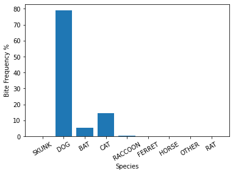

```python
# Get names of all species
data=data.dropna(subset=["SpeciesIDDesc"])
species = data['SpeciesIDDesc'].unique()

# Use count to calculate frequency for each species
count = []
for i in species:
  count.append((data['SpeciesIDDesc'] == i).sum())
# Make count a percentage
count = count/sum(count)*100
# Plot graph with percentage of bite frequency over species
plt.bar(species.astype(str), count)
plt.xticks(rotation=30)
plt.xlabel('Species')
plt.ylabel('Bite Frequency %')
plt.show()
```

We then plot bite frequency over dog species in ascending order. As can be seen from the plot below, there are are several breeds reported in the dataset. However, like before, only some of these breeds occur significantly enough to be analyzed. The breeds that have frequency very close to 0 offer not much significance, and thus, will not be used in the analysis.

Note: We will analyze these graphs later!

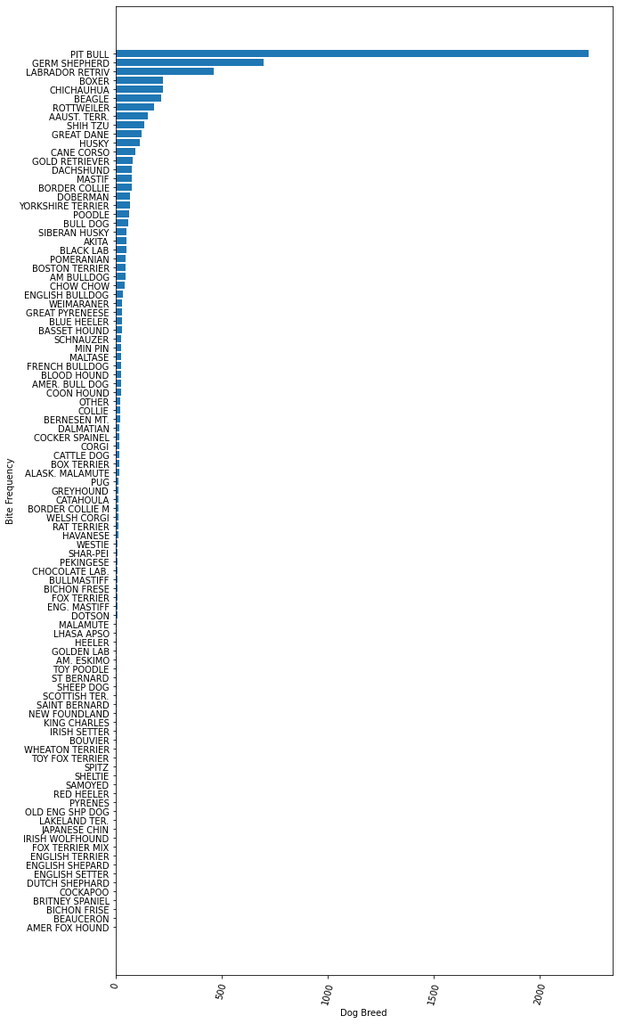

```python
# Get subset with all dog species
sub_data = data.loc[data['SpeciesIDDesc'] == "DOG"]

# Get all names of each breed
dog_s= sub_data['BreedIDDesc'].dropna().unique()
# Use dog_c to contain a list of arrays containing frequency in 1st index and name in 2nd
dog_c = []
for i in dog_s:
  dog_c.append([(sub_data['BreedIDDesc'] == i).sum(),i])
# Sort by 1st index, which is frequency
dog_c.sort()
# Use nums to contain frequency and dog_c to contain list of names
nums=[]
for i in range(len(dog_c)):
    nums.append(dog_c[i][0])
    dog_c[i]=dog_c[i][1]

# Plot graph with bite frequency over dog breed
plt.figure(figsize=(10,20)) # increased the size of the figure to prevent overlapping of y-labels
plt.barh(dog_c,nums)
plt.xlabel('Dog Breed')
plt.ylabel('Bite Frequency')
plt.xticks(rotation=75)
plt.show()
```

As mentioned, we take account into only those breeds that we have significant amount of data for. Thus, from the bar plot above, we extract the top 25 breeds and plot them below.

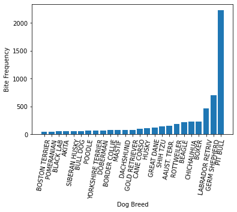

```python
# Take dog breeds with highest bite frequency and plot
sub_data = sub_data.loc[sub_data['BreedIDDesc'].isin(dog_c[74:])]
plt.bar(dog_c[74:],nums[74:]) # extract the top 25 breeds from the plot above
plt.xlabel('Dog Breed')
plt.ylabel('Bite Frequency')
plt.xticks(rotation=80)
plt.show()
```

We take our top 25 dog breeds and plot their bite frequency over year, dropping any rows without year data, as they are not relevant to our analysis. As seen in the first graph below, plotting the other years besides the ones after 2017 are a waste because they barely contain any data, so we cut those out, giving us the second graph with specified years. One of the reasons for missing data before 2017 is the lacking of keeping records.

Now we have graphs where every year has a good amount of data. However, 2022 is not over and the current data is heavily skewed towards the earlier months. Thus, data for 2022 will also be removed so it does not skew the month data. In conclusion, we only consider years 2017-2021.

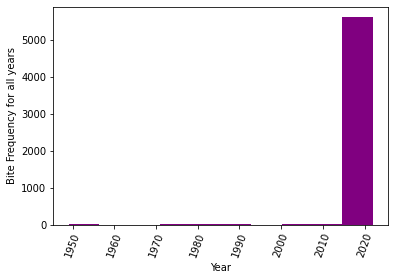

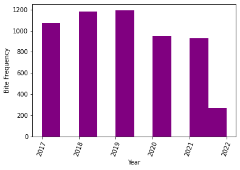

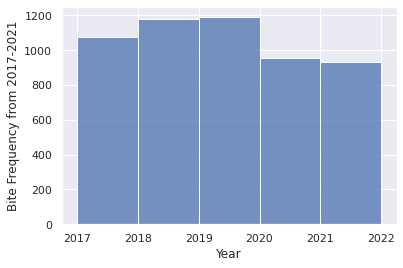

```python
# Plot bite frequency over year of selected breeds

year = sub_data['year']
plt.hist(year, bins = 10, color = "purple")
plt.xticks(rotation=70)
plt.xlabel('Year')
plt.ylabel('Bite Frequency for all years')
plt.show()
# Narrow down to years from 2017 onward
sub_data = sub_data.loc[sub_data['year']>=2017]
year = sub_data['year']
plt.hist(year, bins = 10, color = "purple")
plt.xticks(rotation=70)
plt.xlabel('Year')
plt.ylabel('Bite Frequency')
plt.show()

sub_data = sub_data.loc[sub_data['year']<=2021]
year = sub_data['year']
sns.set()
h = sns.histplot(year, bins=[2017,2018,2019,2020,2021,2022])
plt.xlabel('Year')
plt.ylabel('Bite Frequency from 2017-2021')
h.set_xticks([2017,2018,2019,2020,2021,2022])
plt.show()
```

To get more information based on time, we can plot the bite frequency of the dog breeds over month, dropping any rows without month data that do not provide any value to our analysis.

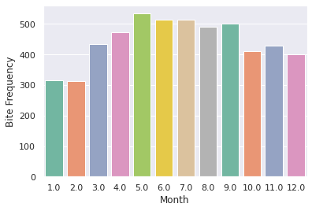

```python
# Plot bite frequency over month
ax = sns.countplot(x="month", data=sub_data , palette="Set2")
plt.xlabel('Month')
plt.ylabel('Bite Frequency')
plt.show()
```

Next, we plot bite frequency over gender to see if there may be a relationship between the two. We drop all the data points that do not have gender of the dog.

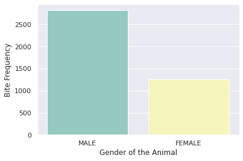

```python
# Plot bite frequency over gender
sub_data = sub_data.loc[sub_data['GenderIDDesc'] != "UNKNOWN"]
ax = sns.countplot(x="GenderIDDesc", data=sub_data , palette="Set3")
plt.xlabel('Gender of the Animal')
plt.ylabel('Bite Frequency')
plt.show()
```

To summarize our steps until now, we visualized several different variables to explore if there is any relationship between them. While doing so, we noticed that missing variables need to be dealt with so that our analysis is not skewed. Thus, we considered data for only dogs, picked top 25% of the dog breeds and removed years that do contain much information. At each step, we reduced some amount of data from our original dataframe. Our final data frame, sub_data, contains the outcome of these steps. This process illustrates an important element of data science pipeline, which is processing the data after doing some explanatory analysis. As we gained insights from the analysis, we adjusted our data processing accordingly to eliminate any skewness or bias in our analysis.

In this next part, we will plot the four visualizations after adjusting the data. Looking at the plots below, some very prominent observations can be made right away.

From graph 1, as can be seen, Pit Bull, German Shepherd, Labrador Retriver, Chichauhua, Rottweiler Beagle, Shihtzu, Great Dane, Husky, etc. are our top contenders with the highest bite frequency. The list accumlated from our dataset corroborates with the general [top 12 list](https://www.keatingfirmlaw.com/post/dogs-most-likely-to-bite) of dog breeds that bite the most.

From graph 2, we see a decrease in the number of bites in the year 2020 and 2021. This is probably because there were fewer people outside due to the COVID-19 pandemic, and thus, fewer cases of people getting bitten.

From graph 3, we see peaks in May, June and July which is the summer season, and thus, more people are outside and more likely to get bit.

From graph 4, as we can see, males are more likely to bite than female dogs. There have many studies conducted that show male dogs are more aggresive and more likely to bite than female dogs [ref](https://www.rspca.org.uk/webContent/staticImages/Downloads/DogAggression.pdf).

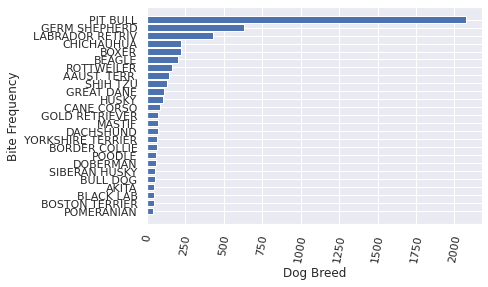

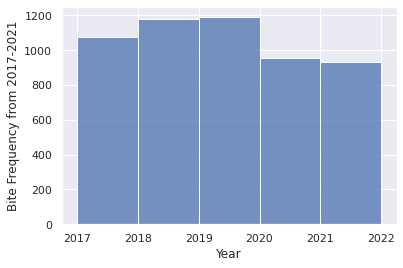

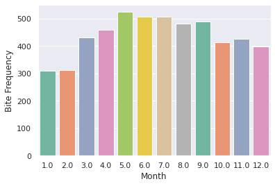

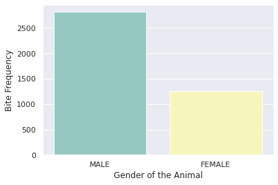

```python
# get all dog breeds and number of said breed
dog_c = []
for i in dog_s:
  dog_c.append([(sub_data['BreedIDDesc'] == i).sum(),i])
dog_c.sort()
nums=[]
# split it into 2 lists
for i in range(len(dog_c)):
    nums.append(dog_c[i][0])
    dog_c[i]=dog_c[i][1]

plt.barh(dog_c[74:],nums[74:])
plt.xlabel('Dog Breed')
plt.ylabel('Bite Frequency')
plt.xticks(rotation=80)
plt.show()

sns.set()
h = sns.histplot(year, bins=[2017,2018,2019,2020,2021,2022])
plt.xlabel('Year')
plt.ylabel('Bite Frequency from 2017-2021')
h.set_xticks([2017,2018,2019,2020,2021,2022])
plt.show()

ax = sns.countplot(x="month", data=sub_data , palette="Set2")
plt.xlabel('Month')
plt.ylabel('Bite Frequency')
plt.show()

ax = sns.countplot(x="GenderIDDesc", data=sub_data , palette="Set3")
plt.xlabel('Gender of the Animal')
plt.ylabel('Bite Frequency')
plt.show()
```

Next, we visualize the location of bites on the body. The plots below show the probability of being bit by female vs male dogs on head or body. Not suprisingly, the probability of being bitten on the body is higher than that of head for both male and female since it covers surface area. Interestingly, both male and female have very similar probaility of biting on the head and the body. Location of the bite doesn't provide much more information for further analysis.

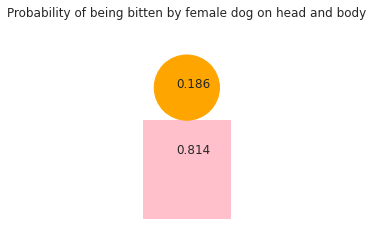

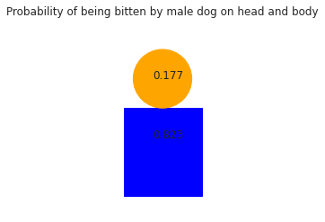

```python
# visualize the probability of getting bit by a female vs male dog on different parts of the body
import matplotlib.patches as patches

head_bites_f = 0
body_bites_f = 0
head_bites_m = 0
body_bites_m = 0

# calculate the count of getting bit by male and female dogs on different parts of the body
for index, row in sub_data.iterrows():
  if row['WhereBittenIDDesc'] == 'HEAD' and row['GenderIDDesc'] == 'FEMALE':
    head_bites_f  += 1
  elif row['WhereBittenIDDesc'] == 'BODY' and row['GenderIDDesc'] == 'FEMALE':
    body_bites_f += 1
  elif row['WhereBittenIDDesc'] == 'HEAD' and row['GenderIDDesc'] == 'MALE':
    head_bites_m  += 1
  elif row['WhereBittenIDDesc'] == 'BODY' and row['GenderIDDesc'] == 'MALE':
    body_bites_m += 1

fig = plt.figure()
ax = fig.add_subplot(111,aspect='equal')
# draw a rectangle to represent the body of the human being
ax.add_patch(
    patches.Rectangle((0.3,0.1),0.4,0.45,color='pink')
)
# draw a circle to represent the head of the human being
circle = plt.Circle((0.5,0.7),0.15,color='orange')
ax.add_artist(circle)
# label the head with the bite probability from female dog
plt.text(0.45,0.7,round(head_bites_f/(head_bites_f + body_bites_f),3))
# label the body with the bite probability from female dog
plt.text(0.45,0.4,round(body_bites_f/(head_bites_f + body_bites_f),3))
plt.title('Probability of being bitten by female dog on head and body')
plt.axis('off')
plt.show()

fig = plt.figure()
ax = fig.add_subplot(111,aspect='equal')
# draw a rectangle to represent the body of the human being
ax.add_patch(
    patches.Rectangle((0.3,0.1),0.4,0.45,color='blue')
)
# draw a circle to represent the head of the human being
circle = plt.Circle((0.5,0.7),0.15,color='orange')
ax.add_artist(circle)
# label the head with the bit probability from male dog
plt.text(0.45,0.7,round(head_bites_m/(head_bites_m + body_bites_m),3))
# label the body with the bit probability from male dog
plt.text(0.45,0.4,round(body_bites_m/(head_bites_m + body_bites_m),3))
plt.title('Probability of being bitten by male dog on head and body')
plt.axis('off')
plt.show()
```

## Hypothesis Testing

Now that we have our data all cleaned up and made some observations, time to see if we can find any relationships. To do that we first do a Z test to see if any particular breed, gender, month, or year makes bites more likely. Our null hypothesis will be that there is no relation between any factor and being bit.

To test this hypothesis we must first determine to what level we are willing to believe the data is not skewed, the Z value.

For this project we will be using 2 sided Z test where z=1.96 for all tests. This Z value in a 2 sided test means there must only be 5% or less chance of there being no relation for us to actually conclude there is a relation. Additionally, we found the diagram in this [resource](https://bloomingtontutors.com/blog/when-to-use-the-z-test-versus-t-test) to be helpful when deciding which type of test should be conducted.

We want to solve for x to know what values the data must be in for us to not reject our hypothesis, as shown in the code below:

```python
def get_interval(z,n,p,q):
    # z=(X-u)/o, X= actual, u=expected, o=std, solve for actual
    return(n*p-z*np.sqrt(n*q*p),z*np.sqrt(n*q*p)+n*p)
```

First up is the breed of the dog. Just from looking at the data it's pretty clear breed has a major impact on getting bitten. But for the sake of science lets just do a Z test to confirm. The values of each breed will be printed along with the interval.

```python
# n, num of data points
n, ignore_me = sub_data.shape

# standard Z value for 95% confidence interval
z=1.96

# Z test of breed.... no need, i mean look at the graph
p=1/25 # chance of getting bitten by a random breed
q=24/25 # the opposite of p
std= np.sqrt(n*q*p)
breed_low, breed_high=get_interval(z,n,p,q)
print(dog_c[74:])
print(nums[74:])
print(breed_low, breed_high)
print(breed_low<= nums[0] and breed_high>=max(nums))
```

[output not shown]

For us to believe there is less than 5% chance of breed not being a factor, no breed can have less than 183 bites or more than 238 bites, which is clearly not the case, there is one dog (Pit Bull) that has over 2000. From this, we can conclude that breeds like Labrador Retrivers, Germen Shepherds, and Pit Bulls almost certainly have higher chances of biting people, especially Pit Bulls.

Next up is gender. From the graph again, it is pretty clear males bite more often. The difference isn't as extreme as it is with the breed but still very clear, so let's do a z test to confirm

```python
# Z test of dependence on gender
p=1/2 # chance of male
q=1/2 # chance of female
std= np.sqrt(n*q*p)
gender_low, gender_high=get_interval(z,n,p,q)
gender_nums=[(sub_data['GenderIDDesc'] == "MALE").sum(),(sub_data['GenderIDDesc'] == "FEMALE").sum()]
print(gender_nums)
print(gender_low, gender_high)
print(gender_low<=min(gender_nums) and gender_high>=max(gender_nums))
```

```
[2816, 1258]
2558.9246596912826 2701.0753403087174
False
```

Yup, there is a less than 5% chance that gender doesn't matter, since both make and female are not in the expected interval of 2558 and 2701 (female 1258). Males bite more often than females.

Next up is the year, there does seem to be a higher concentration of bites in 2018 and 2019 but we are not sure if it's statistically significant yet, and the difference is much less extreme than in the case of breed and gender.

```python
# Z test of dependence on year
# STD = sqrt(n*p*q) p = being x year= 1/6, q = not being x year =5/6
p=1/5 # chance of this year
q=4/5 # chance of not this year
std= np.sqrt(n*q*p)
year_low, year_high=get_interval(z,n,p,q)
year_nums=[]
# go through every year from 2017 to 2021 and get the bites per year
for i in range(2017,2022,1):
    year_nums.append((sub_data['year'] == i).sum())
print(year_nums)
print(year_low, year_high)
print(year_low<=min(year_nums) and year_high>=max(year_nums))
```

```
[1070, 1162, 1158, 940, 930]
995.139727753026 1108.860272246974
False
```

Months, however, will likely give us more useful info, as these months exist every year.

```python
# Z test of dependence on month
p=1/12 # chance of this month
q=11/12 # chance of not this month
std= np.sqrt(n*q*p)
month_low, month_high=get_interval(z,n,p,q)
month_nums=[]
# go through every month and get the bites per month
for i in range(1,13,1):
    month_nums.append((sub_data['month'] == float(i)).sum())
print(month_nums)
print(month_low, month_high)
print(month_low<=min(month_nums) and month_high>=max(month_nums))
```

```
[310, 312, 432, 458, 524, 508, 508, 482, 490, 412, 426, 398]
399.0449607248602 477.62170594180645
False
```

Results again say specific months matter, as there is a less than 5% chance that they don't, with multiple months with values above the upperbound of 477. By observing the graph, the most common times to get bitten is the middle months. But finding the exact change rate from month to month would need some line fitting.

Doing a basical linear regression doesn't really make sense as noted by the below plot

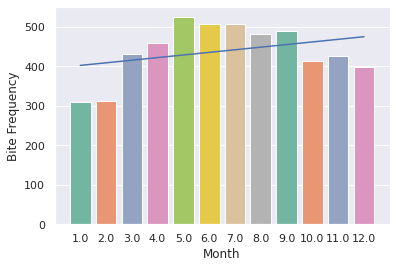

```python
from sklearn.linear_model import LinearRegression
months=np.array([0,1,2,3,4,5,6,7,8,9,10,11])

months=months.reshape((-1, 1))
# create a linear regression fit
month_lin = LinearRegression().fit(months, month_nums)

# graph the bar plot
ax = sns.countplot(x="month", data=sub_data , palette="Set2")

# plot the regression line
plt.plot(months,month_lin.coef_[0]*months+month_lin.intercept_)
plt.xlabel('Month')
plt.ylabel('Bite Frequency')
plt.show()
```

This is because years wrap around itself so after December its January thus it doesn't make sense for it to be a linear increasing or decreasing line. For a better line fitting, we'll look to sin regression.

## Sin Regression Fitting

As the linear regression model in the previous graph was not enough to determine a clear pattern, we turn to sin regression models. Sin regression is a better fit here since a year raps around after, Dec it's Jan, so it makes sense for a bit to have a cycle that repeats itself after a year. First, we calculate the parameters of the equation, using a prediction for p (π+2, x shift), 2π over the number of months in a year for w (period), max frequency minus min frequency for month over 2 for A (amplitude), and max frequency plus min frequency for month over 2 for B (y shift).

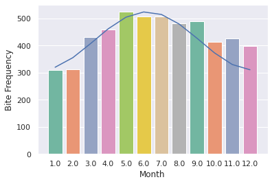

```python
# sin fitting

# Initial variables along with a p guess
A=(max(month_nums)-min(month_nums))/2
B=(max(month_nums)+min(month_nums))/2
w=2*np.pi/12
p=np.pi+2
ax = sns.countplot(x="month", data=sub_data , palette="Set2")

# plot the sin curve with the p value
plt.plot(months,A*np.sin(w*months+p)+B)
plt.xlabel('Month')
plt.ylabel('Bite Frequency')
plt.show()
```

This result is only a guess, to find a more optimal sin regression we must change p (x shift). To do this, we start with an initial guess of π since it can range from 0 to 2π. We then increase or decrease it by half each time depending on which way would decrease the error more, this is repeated 100 times. The resulting sin regression line suggest a peak bite frequency at around July and August, compared to the original sin regression graph's predicted peak at June. According to the weather data [analysis](https://weatherspark.com/y/15227/Average-Weather-in-Louisville-Kentucky-United-States-Year-Round#:~:text=The%20hot%20season%20lasts%20for,low%20of%2070%C2%B0F.) in Louisville, June is the month with most wet days. The weather becomes more pleasant for outdoor activity starting from July. Thus, this explains the peak in July and August as more people are likely to be outside and get bit.

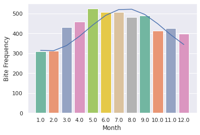

```python
# sin fitting
A=(max(month_nums)-min(month_nums))/2
B=(max(month_nums)+min(month_nums))/2
w=2*np.pi/12
p=np.pi
# month indexing
months=np.array([0,1,2,3,4,5,6,7,8,9,10,11])
adjust=np.pi/2
# loop to optimize p
for i in range(100):
    # get error in both direction
    temper1=A*np.sin(w*months+p+adjust)+B
    std1=np.std(temper1)
    temper2=A*np.sin(w*months+p-adjust)+B
    std2=np.std(temper2)
    #binary search to get search for p's optimal value
    if std2<std1:
        p=p-adjust
    else:
        p=p+adjust
    adjust=adjust/2

# plot the curve
ax = sns.countplot(x="month", data=sub_data , palette="Set2")
plt.plot(months,A*np.sin(w*months+p)+B)
plt.xlabel('Month')
plt.ylabel('Bite Frequency')
plt.show()
```

## Insight and Policy Decisions

Based on our observations through data analysis and modeling, we can conclude that:

- Dogs, regardless of gender, are always more likely to bite the body than the head, with around an 81-82% likelihood vs. the head's 17-18%
- Pit Bulls are by far the most common breed involved in dog bites, with German Shepherd and Labrador Retriever lagging behind in 2nd to 3rd place respectively
- Dog bite incidents tend to be higher in frequency all the way from March to September (Early Spring to Early Fall), appearing to peak at around May, though predictions actually place the peak in late Summer.
- Male dog bites occur more frequently than female

Overall, we can use this currently relevant data to determine the absolute worst time in Louisville, Kentucky to take a walk in the vicinity of a certain dog breed of a specific gender (any point from Spring to Fall around a male Pit Bull). Taking action based on these findings to the extent one is humanly capable *may* reduce the chances of being bitten (especially for children: wearing clothes covering body, avoiding densely populated areas during july and august, and beware of Pit Bulls, German Shepherds, and Labrador Retrievers). Lastly, while the study doesn't explicitly mention, many of these biting cases occur due to teasing or startling the dogs and triggering their aggression [ref](https://www.akc.org/expert-advice/training/why-do-dogs-bite/). Thus, animals should be respected and handled with care!

[figure not shown]